# Project Python Foundations: FoodHub Data Analysis

**Marks: 60**

### Context

The number of restaurants in New York is increasing day by day. Lots of students and busy professionals rely on those restaurants due to their hectic lifestyles. Online food delivery service is a great option for them. It provides them with good food from their favorite restaurants. A food aggregator company FoodHub offers access to multiple restaurants through a single smartphone app.

The app allows the restaurants to receive a direct online order from a customer. The app assigns a delivery person from the company to pick up the order after it is confirmed by the restaurant. The delivery person then uses the map to reach the restaurant and waits for the food package. Once the food package is handed over to the delivery person, he/she confirms the pick-up in the app and travels to the customer's location to deliver the food. The delivery person confirms the drop-off in the app after delivering the food package to the customer. The customer can rate the order in the app. The food aggregator earns money by collecting a fixed margin of the delivery order from the restaurants.

### Objective

The food aggregator company has stored the data of the different orders made by the registered customers in their online portal. They want to analyze the data to get a fair idea about the demand of different restaurants which will help them in enhancing their customer experience. Suppose you are hired as a Data Scientist in this company and the Data Science team has shared some of the key questions that need to be answered. Perform the data analysis to find answers to these questions that will help the company to improve the business.

### Data Description

The data contains the different data related to a food order. The detailed data dictionary is given below.

### Data Dictionary

- order_id: Unique ID of the order
- customer_id: ID of the customer who ordered the food
- restaurant_name: Name of the restaurant
- cuisine_type: Cuisine ordered by the customer
- cost: Cost of the order
- day_of_the_week: Indicates whether the order is placed on a weekday or weekend (The weekday is from Monday to Friday and the weekend is Saturday and Sunday)
- rating: Rating given by the customer out of 5
- food_preparation_time: Time (in minutes) taken by the restaurant to prepare the food. This is calculated by taking the difference between the timestamps of the restaurant's order confirmation and the delivery person's pick-up confirmation.
- delivery_time: Time (in minutes) taken by the delivery person to deliver the food package. This is calculated by taking the difference between the timestamps of the delivery person's pick-up confirmation and drop-off information

### Let us start by importing the required libraries

```python
# The required libraries are imported below. Installation is skipped here so the notebook can run in a local environment.
```

```python
# import libraries for data manipulation
import numpy as np
import pandas as pd

# import libraries for data visualization
import matplotlib.pyplot as plt
import seaborn as sns
```

### Understanding the structure of the data

```python
# uncomment and run the following lines for Google Colab
# from google.colab import drive
# drive.mount('/content/drive')
```

```python
# read the data
import os
csv_path = 'foodhub_order.csv' if os.path.exists('foodhub_order.csv') else '/mnt/data/foodhub_order.csv'
df = pd.read_csv(csv_path)
# returns the first 5 rows
df.head()
```

|  | order_id | customer_id | restaurant_name | cuisine_type | cost_of_the_order | day_of_the_week | rating | food_preparation_time | delivery_time |
| --- | --- | --- | --- | --- | --- | --- | --- | --- | --- |
| 0 | 1477147 | 337525 | Hangawi | Korean | 30.75 | Weekend | Not given | 25 | 20 |
| 1 | 1477685 | 358141 | Blue Ribbon Sushi Izakaya | Japanese | 12.08 | Weekend | Not given | 25 | 23 |
| 2 | 1477070 | 66393 | Cafe Habana | Mexican | 12.23 | Weekday | 5 | 23 | 28 |
| 3 | 1477334 | 106968 | Blue Ribbon Fried Chicken | American | 29.20 | Weekend | 3 | 25 | 15 |
| 4 | 1478249 | 76942 | Dirty Bird to Go | American | 11.59 | Weekday | 4 | 25 | 24 |

#### Observations:

The DataFrame has 9 columns as mentioned in the Data Dictionary. Data in each row corresponds to the order placed by a customer.

### **Question 1:** How many rows and columns are present in the data? [0.5 mark]

```python
# Check the shape of the dataset
rows, columns = df.shape
print(f'The dataset has {rows} rows and {columns} columns.')
df.shape
```

```
The dataset has 1898 rows and 9 columns.
```

```
(1898, 9)
```

#### Observations:

- The dataset contains 1,898 rows and 9 columns.
- Each row represents one FoodHub order, and each column captures order, customer, restaurant, cuisine, cost, rating, and timing information.

### **Question 2:** What are the datatypes of the different columns in the dataset? (The info() function can be used) [0.5 mark]

```python
# Check column datatypes and non-null counts
df.info()
```

```
<class 'pandas.core.frame.DataFrame'>
RangeIndex: 1898 entries, 0 to 1897
Data columns (total 9 columns):
 #   Column                 Non-Null Count  Dtype
---  ------                 --------------  -----
 0   order_id               1898 non-null   int64
 1   customer_id            1898 non-null   int64
 2   restaurant_name        1898 non-null   object
 3   cuisine_type           1898 non-null   object
 4   cost_of_the_order      1898 non-null   float64
 5   day_of_the_week        1898 non-null   object
 6   rating                 1898 non-null   object
 7   food_preparation_time  1898 non-null   int64
 8   delivery_time          1898 non-null   int64
dtypes: float64(1), int64(4), object(4)
memory usage: 133.6+ KB
```

#### Observations:

- The dataset has 5 numeric columns: `order_id`, `customer_id`, `cost_of_the_order`, `food_preparation_time`, and `delivery_time`.
- It has 4 object/categorical columns: `restaurant_name`, `cuisine_type`, `day_of_the_week`, and `rating`.
- `rating` is stored as an object because unrated orders are marked as "Not given".

### **Question 3:** Are there any missing values in the data? If yes, treat them using an appropriate method. [1 mark]

```python
# Check missing values in each column
df.isnull().sum()
```

```
order_id                 0
customer_id              0
restaurant_name          0
cuisine_type             0
cost_of_the_order        0
day_of_the_week          0
rating                   0
food_preparation_time    0
delivery_time            0
dtype: int64
```

#### Observations:

- There are no missing values in any column.
- The `rating` column contains the value "Not given", which represents orders that were not rated. This is not a null value, so it is handled separately during rating-based analysis.

### **Question 4:** Check the statistical summary of the data. What is the minimum, average, and maximum time it takes for food to be prepared once an order is placed? [2 marks]

```python
# Statistical summary of the numerical columns
df.describe().T
```

|  | count | mean | std | min | 25% | 50% | 75% | max |
| --- | --- | --- | --- | --- | --- | --- | --- | --- |
| order_id | 1898.0 | 1.477496e+06 | 548.049724 | 1476547.00 | 1477021.25 | 1477495.50 | 1.477970e+06 | 1478444.00 |
| customer_id | 1898.0 | 1.711685e+05 | 113698.139743 | 1311.00 | 77787.75 | 128600.00 | 2.705250e+05 | 405334.00 |
| cost_of_the_order | 1898.0 | 1.649885e+01 | 7.483812 | 4.47 | 12.08 | 14.14 | 2.229750e+01 | 35.41 |
| food_preparation_time | 1898.0 | 2.737197e+01 | 4.632481 | 20.00 | 23.00 | 27.00 | 3.100000e+01 | 35.00 |
| delivery_time | 1898.0 | 2.416175e+01 | 4.972637 | 15.00 | 20.00 | 25.00 | 2.800000e+01 | 33.00 |

#### Observations:

- The food preparation time ranges from 20 minutes to 35 minutes.
- The average food preparation time is approximately 27.37 minutes.
- The median order cost is $14.14, while the maximum order cost is $35.41.

### **Question 5:** How many orders are not rated? [1 mark]

```python
# Count orders that were not rated
not_rated_orders = (df['rating'] == 'Not given').sum()
print(f'The number of orders not rated is {not_rated_orders}.')
```

```
The number of orders not rated is 736.
```

#### Observations:

- 736 orders were not rated by customers.
- This is a sizable share of the dataset, so rating analysis should exclude these records or treat them as unrated instead of numeric ratings.

### Exploratory Data Analysis (EDA)

### **Question 6:** Explore all the variables and provide observations on their distributions. (Generally, histograms, boxplots, countplots, etc. are used for univariate exploration.) [9 marks]

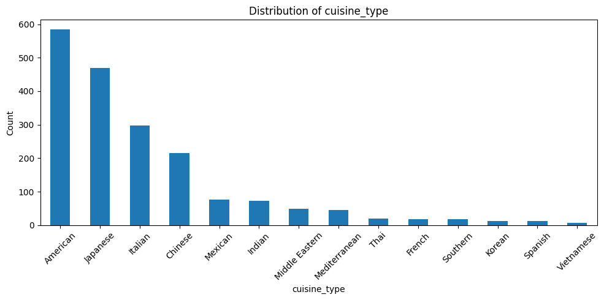

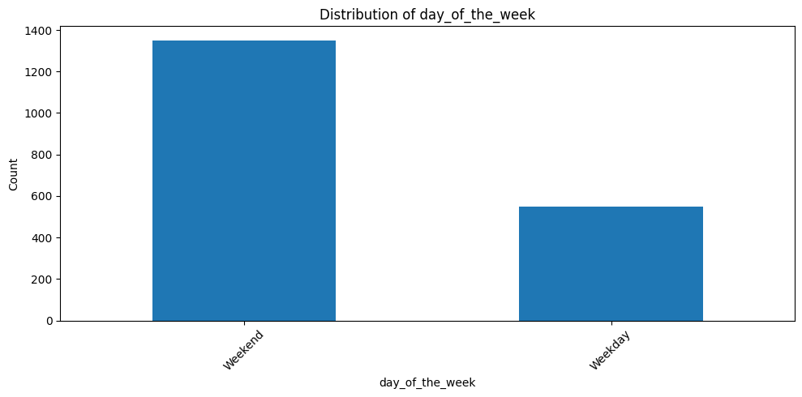

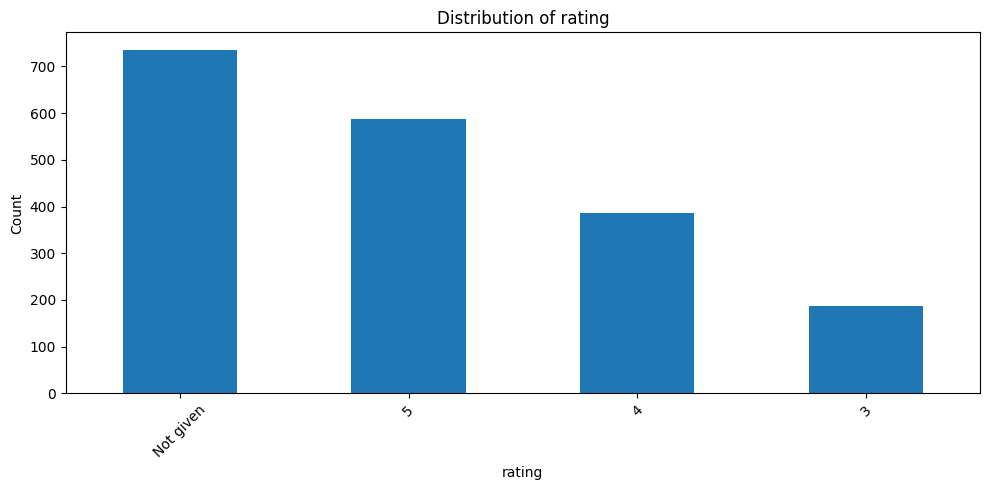

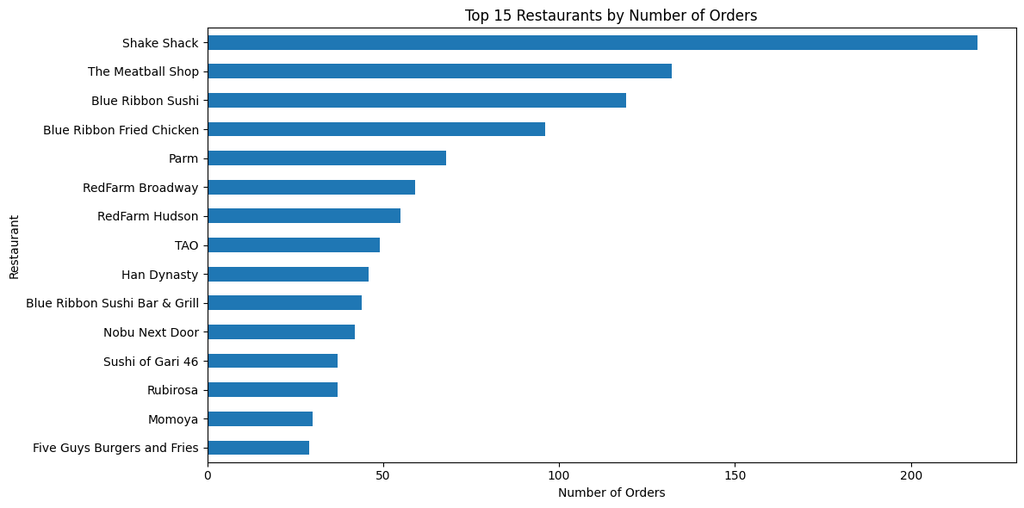

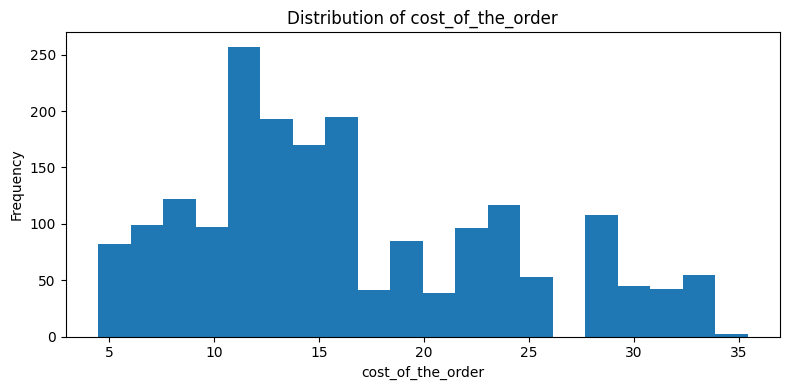

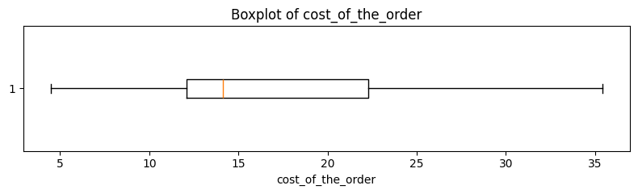

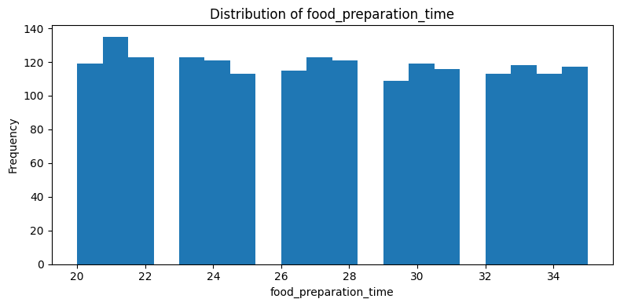

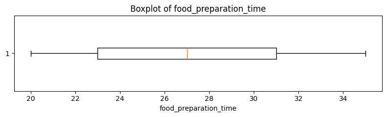

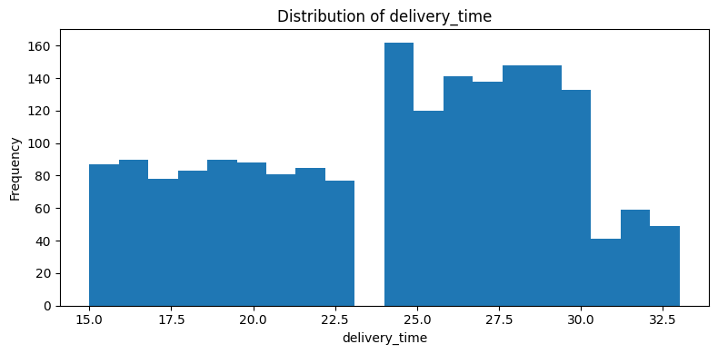

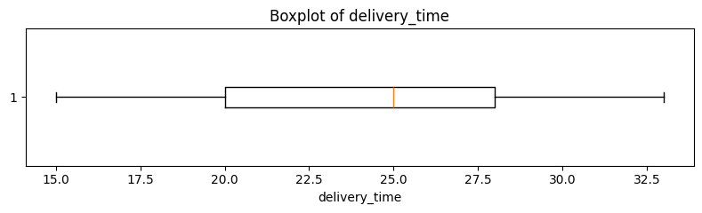

```
Unique restaurants: 178

Cuisine counts:
cuisine_type
American          584
Japanese          470
Italian           298
Chinese           215
Mexican            77
Indian             73
Middle Eastern     49
Mediterranean      46
Thai               19
French             18
Southern           17
Korean             13
Spanish            12
Vietnamese          7
Name: count, dtype: int64

Day of week counts:
day_of_the_week
Weekend    1351
Weekday     547
Name: count, dtype: int64

Rating counts:
rating
Not given    736
5            588
4            386
3            188
Name: count, dtype: int64
```

```python
# Univariate analysis of categorical and numerical variables
plt.rcParams.update({'figure.autolayout': True})

# Categorical columns
categorical_cols = ['cuisine_type', 'day_of_the_week', 'rating']
for col in categorical_cols:
    plt.figure(figsize=(10, 5))
    df[col].value_counts().plot(kind='bar')
    plt.title(f'Distribution of {col}')
    plt.xlabel(col)
    plt.ylabel('Count')
    plt.xticks(rotation=45)
    plt.show()

# Top 15 restaurants by number of orders
plt.figure(figsize=(12, 6))
top_restaurants = df['restaurant_name'].value_counts().head(15)
top_restaurants.sort_values().plot(kind='barh')
plt.title('Top 15 Restaurants by Number of Orders')
plt.xlabel('Number of Orders')
plt.ylabel('Restaurant')
plt.show()

# Numerical columns
numerical_cols = ['cost_of_the_order', 'food_preparation_time', 'delivery_time']
for col in numerical_cols:
    plt.figure(figsize=(8, 4))
    df[col].plot(kind='hist', bins=20)
    plt.title(f'Distribution of {col}')
    plt.xlabel(col)
    plt.show()

    plt.figure(figsize=(8, 2.5))
    plt.boxplot(df[col], vert=False)
    plt.title(f'Boxplot of {col}')
    plt.xlabel(col)
    plt.show()

print('Unique restaurants:', df['restaurant_name'].nunique())
print('\nCuisine counts:')
print(df['cuisine_type'].value_counts())
print('\nDay of week counts:')
print(df['day_of_the_week'].value_counts())
print('\nRating counts:')
print(df['rating'].value_counts())
```

### Question 7: Which are the top 5 restaurants in terms of the number of orders received? [1 mark]

#### Observations from univariate analysis:

- FoodHub orders are concentrated among a few cuisines, especially American, Japanese, Italian, and Chinese.
- Most orders are placed on the weekend.
- The most common numeric rating is 5, but many orders are marked Not given.
- `cost_of_the_order` is right-skewed, with many orders around the mid-price range and fewer high-cost orders.
- Food preparation time is spread between 20 and 35 minutes, while delivery time ranges from 15 to 33 minutes.

```python
# Top 5 restaurants by number of orders
top_5_restaurants = df['restaurant_name'].value_counts().head(5)
top_5_restaurants
```

```
restaurant_name
Shake Shack                  219
The Meatball Shop            132
Blue Ribbon Sushi            119
Blue Ribbon Fried Chicken     96
Parm                          68
Name: count, dtype: int64
```

#### Observations:

- The top 5 restaurants by order count are Shake Shack, The Meatball Shop, Blue Ribbon Sushi, Blue Ribbon Fried Chicken, and Parm.
- Shake Shack received the highest number of orders with 219 orders.

### **Question 8**: Which is the most popular cuisine on weekends? [1 mark]

```python
# Most popular cuisine on weekends
weekend_orders = df[df['day_of_the_week'] == 'Weekend']
weekend_cuisine_counts = weekend_orders['cuisine_type'].value_counts()
weekend_cuisine_counts
```

```
cuisine_type
American          415
Japanese          335
Italian           207
Chinese           163
Mexican            53
Indian             49
Middle Eastern     32
Mediterranean      32
Thai               15
French             13
Korean             11
Southern           11
Spanish            11
Vietnamese          4
Name: count, dtype: int64
```

#### Observations:

- American cuisine is the most popular cuisine on weekends, with 415 weekend orders.
- Japanese and Italian cuisines are the next most popular weekend choices.

### **Question 9**: What percentage of the orders cost more than 20 dollars? [2 marks]

```python
# Percentage of orders costing more than $20
orders_above_20 = df[df['cost_of_the_order'] > 20]
percentage_above_20 = len(orders_above_20) / len(df) * 100
print(f'Number of orders above $20: {len(orders_above_20)}')
print(f'Percentage of orders above $20: {percentage_above_20:.2f}%')
```

```
Number of orders above $20: 555
Percentage of orders above $20: 29.24%
```

#### Observations:

- 555 orders cost more than $20.
- This represents approximately 29.24% of all orders.

### **Question 10**: What is the mean order delivery time? [1 mark]

```python
# Mean order delivery time
mean_delivery_time = df['delivery_time'].mean()
print(f'The mean delivery time is {mean_delivery_time:.2f} minutes.')
```

```
The mean delivery time is 24.16 minutes.
```

#### Observations:

- The average delivery time is approximately 24.16 minutes.

### **Question 11:** The company has decided to give 20% discount vouchers to the top 5 most frequent customers. Find the IDs of these customers and the number of orders they placed. [1 mark]

```python
# Top 5 most frequent customers
top_5_customers = df['customer_id'].value_counts().head(5).reset_index()
top_5_customers.columns = ['customer_id', 'number_of_orders']
top_5_customers
```

|  | customer_id | number_of_orders |
| --- | --- | --- |
| 0 | 52832 | 13 |
| 1 | 47440 | 10 |
| 2 | 83287 | 9 |
| 3 | 250494 | 8 |
| 4 | 65009 | 7 |

#### Observations:

- The top 5 customer IDs are 52832, 47440, 83287, 250494, and 65009.
- Customer 52832 placed the most orders, with 13 orders.

### **Question 12**: Perform a multivariate analysis to explore relationships between the important variables in the dataset. (It is a good idea to explore relations between numerical variables as well as relations between numerical and categorical variables) [10 marks]

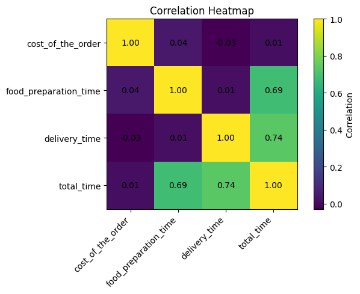

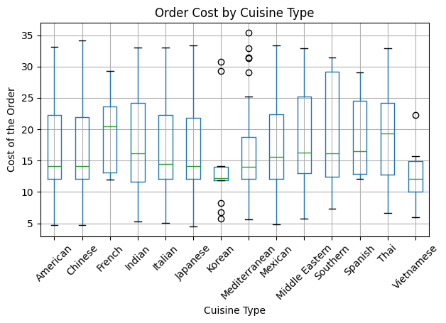

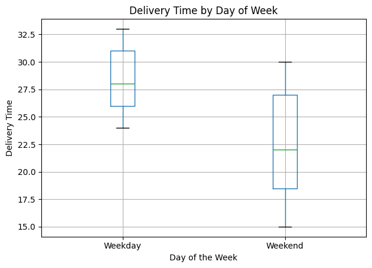

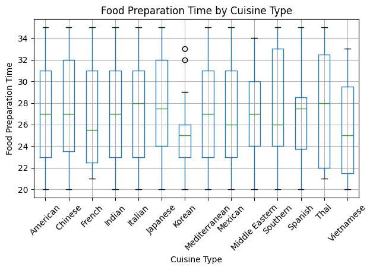

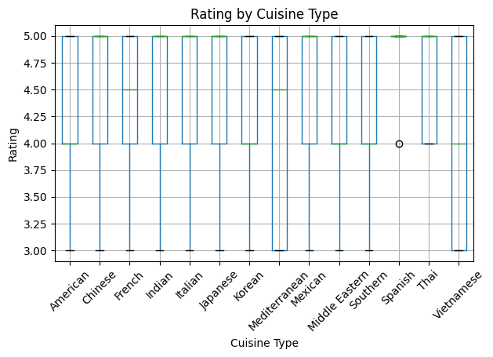

| cuisine_type | order_count | avg_rating | avg_cost | avg_prep_time | avg_delivery_time |
| --- | --- | --- | --- | --- | --- |
| American | 368 | 4.298913 | 16.812989 | 27.388587 | 24.396739 |
| Japanese | 273 | 4.373626 | 16.345641 | 27.652015 | 23.743590 |
| Italian | 172 | 4.360465 | 17.135930 | 27.627907 | 25.209302 |
| Chinese | 133 | 4.338346 | 16.186541 | 27.977444 | 23.496241 |
| Indian | 50 | 4.540000 | 16.663400 | 26.280000 | 23.300000 |
| Mexican | 48 | 4.416667 | 16.319375 | 25.854167 | 24.770833 |
| Middle Eastern | 34 | 4.235294 | 20.075882 | 26.676471 | 24.617647 |
| Mediterranean | 32 | 4.218750 | 15.892500 | 27.875000 | 23.187500 |
| Southern | 13 | 4.307692 | 18.806154 | 27.153846 | 22.615385 |
| French | 10 | 4.300000 | 20.087000 | 26.600000 | 25.100000 |
| Korean | 9 | 4.111111 | 13.142222 | 25.333333 | 21.111111 |
| Thai | 9 | 4.666667 | 19.185556 | 26.888889 | 23.000000 |
| Spanish | 6 | 4.833333 | 19.718333 | 25.333333 | 22.500000 |
| Vietnamese | 5 | 4.000000 | 12.806000 | 24.200000 | 27.200000 |

```python
# Multivariate analysis
rated_df = df[df['rating'] != 'Not given'].copy()
rated_df['rating'] = rated_df['rating'].astype(int)

df['total_time'] = df['food_preparation_time'] + df['delivery_time']

# Relationship between cost, preparation time, and delivery time
corr = df[['cost_of_the_order', 'food_preparation_time', 'delivery_time', 'total_time']].corr()
plt.figure(figsize=(7, 5))
plt.imshow(corr)
plt.xticks(range(len(corr.columns)), corr.columns, rotation=45, ha='right')
plt.yticks(range(len(corr.columns)), corr.columns)
plt.colorbar(label='Correlation')
for i in range(len(corr.columns)):
    for j in range(len(corr.columns)):
        plt.text(j, i, f'{corr.iloc[i, j]:.2f}', ha='center', va='center')
plt.title('Correlation Heatmap')
plt.show()

# Cost by cuisine type
plt.figure(figsize=(12, 6))
df.boxplot(column='cost_of_the_order', by='cuisine_type', rot=45)
plt.title('Order Cost by Cuisine Type')
plt.suptitle('')
plt.xlabel('Cuisine Type')
plt.ylabel('Cost of the Order')
plt.show()

# Delivery time by day of week
plt.figure(figsize=(7, 5))
df.boxplot(column='delivery_time', by='day_of_the_week')
plt.title('Delivery Time by Day of Week')
plt.suptitle('')
plt.xlabel('Day of the Week')
plt.ylabel('Delivery Time')
plt.show()

# Food preparation time by cuisine type
plt.figure(figsize=(12, 6))
df.boxplot(column='food_preparation_time', by='cuisine_type', rot=45)
plt.title('Food Preparation Time by Cuisine Type')
plt.suptitle('')
plt.xlabel('Cuisine Type')
plt.ylabel('Food Preparation Time')
plt.show()

# Rating by cuisine type
plt.figure(figsize=(12, 6))
rated_df.boxplot(column='rating', by='cuisine_type', rot=45)
plt.title('Rating by Cuisine Type')
plt.suptitle('')
plt.xlabel('Cuisine Type')
plt.ylabel('Rating')
plt.show()

# Average metrics by cuisine
cuisine_summary = rated_df.groupby('cuisine_type').agg(
    order_count=('order_id', 'count'),
    avg_rating=('rating', 'mean'),
    avg_cost=('cost_of_the_order', 'mean'),
    avg_prep_time=('food_preparation_time', 'mean'),
    avg_delivery_time=('delivery_time', 'mean')
).sort_values('order_count', ascending=False)

cuisine_summary
```

#### Observations:

- There is very little linear correlation between order cost, food preparation time, and delivery time.
- Weekend orders have noticeably lower delivery times than weekday orders.
- American, Japanese, Italian, and Chinese cuisines drive most of the rated order volume.
- Some lower-volume cuisines, such as Spanish and Thai, show high average ratings, but their order counts are small, so those averages should be interpreted carefully.

### **Question 13:** The company wants to provide a promotional offer in the advertisement of the restaurants. The condition to get the offer is that the restaurants must have a rating count of more than 50 and the average rating should be greater than 4. Find the restaurants fulfilling the criteria to get the promotional offer. [3 marks]

```python
# Restaurants with rating count > 50 and average rating > 4
rated_df = df[df['rating'] != 'Not given'].copy()
rated_df['rating'] = rated_df['rating'].astype(int)

restaurant_rating_summary = rated_df.groupby('restaurant_name')['rating'].agg(['count', 'mean']).reset_index()
promo_restaurants = restaurant_rating_summary[(restaurant_rating_summary['count'] > 50) & (restaurant_rating_summary['mean'] > 4)]
promo_restaurants = promo_restaurants.sort_values(['mean', 'count'], ascending=[False, False])
promo_restaurants
```

|  | restaurant_name | count | mean |
| --- | --- | --- | --- |
| 132 | The Meatball Shop | 84 | 4.511905 |
| 16 | Blue Ribbon Fried Chicken | 64 | 4.328125 |
| 117 | Shake Shack | 133 | 4.278195 |
| 17 | Blue Ribbon Sushi | 73 | 4.219178 |

#### Observations:

- The restaurants that qualify for the promotional offer are The Meatball Shop, Blue Ribbon Fried Chicken, Shake Shack, and Blue Ribbon Sushi.
- These restaurants have more than 50 ratings and an average rating above 4.

### **Question 14:** The company charges the restaurant 25% on the orders having cost greater than 20 dollars and 15% on the orders having cost greater than 5 dollars. Find the net revenue generated by the company across all orders. [3 marks]

```python
# Calculate net revenue generated by FoodHub
# Commission rules:
# 25% on orders costing more than $20
# 15% on orders costing more than $5 and up to $20
# 0% on orders costing $5 or less

def calculate_commission(cost):
    if cost > 20:
        return cost * 0.25
    elif cost > 5:
        return cost * 0.15
    else:
        return 0

df['commission'] = df['cost_of_the_order'].apply(calculate_commission)
net_revenue = df['commission'].sum()
print(f'The net revenue generated by FoodHub is ${net_revenue:.2f}.')
```

```
The net revenue generated by FoodHub is $6166.30.
```

#### Observations:

- The net revenue generated by FoodHub from commissions is approximately $6,166.30.

### **Question 15:** The company wants to analyze the total time required to deliver the food. What percentage of orders take more than 60 minutes to get delivered from the time the order is placed? (The food has to be prepared and then delivered.) [2 marks]

```python
# Percentage of orders with total delivery process time greater than 60 minutes
df['total_time'] = df['food_preparation_time'] + df['delivery_time']
orders_above_60 = df[df['total_time'] > 60]
percentage_above_60 = len(orders_above_60) / len(df) * 100
print(f'Number of orders taking more than 60 minutes: {len(orders_above_60)}')
print(f'Percentage of orders taking more than 60 minutes: {percentage_above_60:.2f}%')
```

```
Number of orders taking more than 60 minutes: 200
Percentage of orders taking more than 60 minutes: 10.54%
```

#### Observations:

- 200 orders take more than 60 minutes from order placement to delivery.
- This represents approximately 10.54% of all orders.

### **Question 16:** The company wants to analyze the delivery time of the orders on weekdays and weekends. How does the mean delivery time vary during weekdays and weekends? [2 marks]

```python
# Mean delivery time by day of the week
mean_delivery_by_day = df.groupby('day_of_the_week')['delivery_time'].mean().reset_index()
mean_delivery_by_day
```

|  | day_of_the_week | delivery_time |
| --- | --- | --- |
| 0 | Weekday | 28.340037 |
| 1 | Weekend | 22.470022 |

#### Observations:

- The mean delivery time is approximately 28.34 minutes on weekdays and 22.47 minutes on weekends.
- Weekday deliveries take about 5.87 minutes longer on average than weekend deliveries.

### Conclusion and Recommendations

### **Question 17:** What are your conclusions from the analysis? What recommendations would you like to share to help improve the business? (You can use cuisine type and feedback ratings to drive your business recommendations.) [6 marks]

### Conclusions:

- The dataset contains 1,898 orders across 178 restaurants and 14 cuisine types.
- Demand is concentrated on weekends, which account for about 71% of all orders.
- The most ordered cuisines are American, Japanese, Italian, and Chinese.
- Shake Shack, The Meatball Shop, Blue Ribbon Sushi, Blue Ribbon Fried Chicken, and Parm are the top restaurants by order volume.
- The average food preparation time is about 27.37 minutes, and the average delivery time is about 24.16 minutes.
- Weekday deliveries are slower than weekend deliveries, with an average of 28.34 minutes compared with 22.47 minutes on weekends.
- About 29.24% of orders cost more than $20, and these orders are important because they generate higher commission revenue.
- The company generated approximately $6,166.30 in net commission revenue from the orders in this dataset.
- A large number of orders, 736, were not rated, which limits the usefulness of customer feedback analysis.

### Recommendations:

- Prioritize partnerships, promotions, and app placement for high-volume cuisines, especially American, Japanese, Italian, and Chinese, because these categories drive most demand.
- Offer promotional support to restaurants that meet the rating criteria: The Meatball Shop, Blue Ribbon Fried Chicken, Shake Shack, and Blue Ribbon Sushi.
- Investigate weekday delivery operations because weekday delivery time is meaningfully higher than weekend delivery time. More delivery partners or better routing may be needed during weekday demand peaks.
- Encourage more customers to submit ratings, for example through small loyalty points or post-delivery reminders, because many orders are currently marked Not given.
- Use targeted vouchers for the top frequent customers, especially customer IDs 52832, 47440, 83287, 250494, and 65009, to improve retention.
- Focus upselling and bundled offers around orders near the $20 threshold, since orders above $20 generate the highest commission rate.